# Risk Factor Analysis

## Outcome Variable

**Outcome Variable:** whz

## Predictor Variables

**Intervention Variable:** month

**Adjustment Set:**

unadjusted

## Stratifying Variables

The analysis was stratified on these variable(s):

- agecat
- studyid
- country

## Data Summary

| agecat | studyid | country | month | n_cell | n | outcome_variable |
| --- | --- | --- | --- | --- | --- | --- |
| Birth | ki0047075b-MAL-ED | BANGLADESH | 1 | 20 | 215 | whz |
| Birth | ki0047075b-MAL-ED | BANGLADESH | 2 | 18 | 215 | whz |
| Birth | ki0047075b-MAL-ED | BANGLADESH | 3 | 23 | 215 | whz |
| Birth | ki0047075b-MAL-ED | BANGLADESH | 4 | 21 | 215 | whz |
| Birth | ki0047075b-MAL-ED | BANGLADESH | 5 | 17 | 215 | whz |
| Birth | ki0047075b-MAL-ED | BANGLADESH | 6 | 6 | 215 | whz |
| Birth | ki0047075b-MAL-ED | BANGLADESH | 7 | 12 | 215 | whz |
| Birth | ki0047075b-MAL-ED | BANGLADESH | 8 | 24 | 215 | whz |
| Birth | ki0047075b-MAL-ED | BANGLADESH | 9 | 16 | 215 | whz |
| Birth | ki0047075b-MAL-ED | BANGLADESH | 10 | 19 | 215 | whz |
| Birth | ki0047075b-MAL-ED | BANGLADESH | 11 | 13 | 215 | whz |
| Birth | ki0047075b-MAL-ED | BANGLADESH | 12 | 26 | 215 | whz |
| Birth | ki0047075b-MAL-ED | BRAZIL | 1 | 5 | 62 | whz |
| Birth | ki0047075b-MAL-ED | BRAZIL | 2 | 8 | 62 | whz |
| Birth | ki0047075b-MAL-ED | BRAZIL | 3 | 9 | 62 | whz |
| Birth | ki0047075b-MAL-ED | BRAZIL | 4 | 5 | 62 | whz |
| Birth | ki0047075b-MAL-ED | BRAZIL | 5 | 1 | 62 | whz |
| Birth | ki0047075b-MAL-ED | BRAZIL | 6 | 5 | 62 | whz |
| Birth | ki0047075b-MAL-ED | BRAZIL | 7 | 5 | 62 | whz |
| Birth | ki0047075b-MAL-ED | BRAZIL | 8 | 6 | 62 | whz |
| Birth | ki0047075b-MAL-ED | BRAZIL | 9 | 6 | 62 | whz |
| Birth | ki0047075b-MAL-ED | BRAZIL | 10 | 4 | 62 | whz |
| Birth | ki0047075b-MAL-ED | BRAZIL | 11 | 5 | 62 | whz |
| Birth | ki0047075b-MAL-ED | BRAZIL | 12 | 3 | 62 | whz |
| Birth | ki0047075b-MAL-ED | INDIA | 1 | 2 | 45 | whz |
| Birth | ki0047075b-MAL-ED | INDIA | 2 | 3 | 45 | whz |
| Birth | ki0047075b-MAL-ED | INDIA | 3 | 5 | 45 | whz |
| Birth | ki0047075b-MAL-ED | INDIA | 4 | 6 | 45 | whz |
| Birth | ki0047075b-MAL-ED | INDIA | 5 | 2 | 45 | whz |
| Birth | ki0047075b-MAL-ED | INDIA | 6 | 3 | 45 | whz |

[output cut: 774 more lines]

The following strata were considered:

- agecat: 24 months, studyid: ki0047075b-MAL-ED, country: BANGLADESH
- agecat: 24 months, studyid: ki0047075b-MAL-ED, country: BRAZIL
- agecat: 24 months, studyid: ki0047075b-MAL-ED, country: INDIA
- agecat: 24 months, studyid: ki0047075b-MAL-ED, country: NEPAL
- agecat: 24 months, studyid: ki0047075b-MAL-ED, country: PERU
- agecat: 24 months, studyid: ki0047075b-MAL-ED, country: SOUTH AFRICA
- agecat: 24 months, studyid: ki0047075b-MAL-ED, country: TANZANIA, UNITED REPUBLIC OF
- agecat: 24 months, studyid: ki1000108-CMC-V-BCS-2002, country: INDIA
- agecat: 24 months, studyid: ki1000108-IRC, country: INDIA
- agecat: 24 months, studyid: ki1000109-EE, country: PAKISTAN
- agecat: 24 months, studyid: ki1017093-NIH-Birth, country: BANGLADESH
- agecat: 24 months, studyid: ki1066203-TanzaniaChild2, country: TANZANIA, UNITED REPUBLIC OF
- agecat: 24 months, studyid: ki1101329-Keneba, country: GAMBIA
- agecat: 24 months, studyid: ki1113344-GMS-Nepal, country: NEPAL
- agecat: 24 months, studyid: ki1114097-CMIN, country: BANGLADESH
- agecat: 24 months, studyid: ki1114097-CONTENT, country: PERU
- agecat: 24 months, studyid: ki1119695-PROBIT, country: BELARUS
- agecat: 24 months, studyid: ki1126311-ZVITAMBO, country: ZIMBABWE
- agecat: 24 months, studyid: ki1148112-LCNI-5, country: MALAWI
- agecat: 24 months, studyid: kiGH5241-JiVitA-3, country: BANGLADESH
- agecat: 24 months, studyid: kiGH5241-JiVitA-4, country: BANGLADESH
- agecat: 6 months, studyid: ki0047075b-MAL-ED, country: BANGLADESH
- agecat: 6 months, studyid: ki0047075b-MAL-ED, country: BRAZIL
- agecat: 6 months, studyid: ki0047075b-MAL-ED, country: INDIA
- agecat: 6 months, studyid: ki0047075b-MAL-ED, country: NEPAL
- agecat: 6 months, studyid: ki0047075b-MAL-ED, country: PERU
- agecat: 6 months, studyid: ki0047075b-MAL-ED, country: SOUTH AFRICA
- agecat: 6 months, studyid: ki0047075b-MAL-ED, country: TANZANIA, UNITED REPUBLIC OF
- agecat: 6 months, studyid: ki1000108-CMC-V-BCS-2002, country: INDIA
- agecat: 6 months, studyid: ki1000108-IRC, country: INDIA
- agecat: 6 months, studyid: ki1000109-EE, country: PAKISTAN
- agecat: 6 months, studyid: ki1000109-ResPak, country: PAKISTAN
- agecat: 6 months, studyid: ki1000304b-SAS-CompFeed, country: INDIA
- agecat: 6 months, studyid: ki1000304b-SAS-FoodSuppl, country: INDIA
- agecat: 6 months, studyid: ki1017093-NIH-Birth, country: BANGLADESH
- agecat: 6 months, studyid: ki1066203-TanzaniaChild2, country: TANZANIA, UNITED REPUBLIC OF
- agecat: 6 months, studyid: ki1101329-Keneba, country: GAMBIA
- agecat: 6 months, studyid: ki1112895-Guatemala BSC, country: GUATEMALA
- agecat: 6 months, studyid: ki1113344-GMS-Nepal, country: NEPAL
- agecat: 6 months, studyid: ki1114097-CMIN, country: BANGLADESH
- agecat: 6 months, studyid: ki1114097-CONTENT, country: PERU
- agecat: 6 months, studyid: ki1119695-PROBIT, country: BELARUS
- agecat: 6 months, studyid: ki1126311-ZVITAMBO, country: ZIMBABWE
- agecat: 6 months, studyid: ki1148112-LCNI-5, country: MALAWI
- agecat: 6 months, studyid: kiGH5241-JiVitA-3, country: BANGLADESH
- agecat: 6 months, studyid: kiGH5241-JiVitA-4, country: BANGLADESH
- agecat: Birth, studyid: ki0047075b-MAL-ED, country: BANGLADESH
- agecat: Birth, studyid: ki0047075b-MAL-ED, country: BRAZIL
- agecat: Birth, studyid: ki0047075b-MAL-ED, country: INDIA
- agecat: Birth, studyid: ki0047075b-MAL-ED, country: NEPAL
- agecat: Birth, studyid: ki0047075b-MAL-ED, country: PERU
- agecat: Birth, studyid: ki0047075b-MAL-ED, country: SOUTH AFRICA
- agecat: Birth, studyid: ki0047075b-MAL-ED, country: TANZANIA, UNITED REPUBLIC OF
- agecat: Birth, studyid: ki1000108-CMC-V-BCS-2002, country: INDIA
- agecat: Birth, studyid: ki1000108-IRC, country: INDIA
- agecat: Birth, studyid: ki1000109-EE, country: PAKISTAN
- agecat: Birth, studyid: ki1000109-ResPak, country: PAKISTAN
- agecat: Birth, studyid: ki1000304b-SAS-CompFeed, country: INDIA
- agecat: Birth, studyid: ki1017093-NIH-Birth, country: BANGLADESH
- agecat: Birth, studyid: ki1101329-Keneba, country: GAMBIA
- agecat: Birth, studyid: ki1113344-GMS-Nepal, country: NEPAL
- agecat: Birth, studyid: ki1114097-CMIN, country: BANGLADESH
- agecat: Birth, studyid: ki1114097-CONTENT, country: PERU
- agecat: Birth, studyid: ki1119695-PROBIT, country: BELARUS
- agecat: Birth, studyid: ki1126311-ZVITAMBO, country: ZIMBABWE
- agecat: Birth, studyid: kiGH5241-JiVitA-3, country: BANGLADESH
- agecat: Birth, studyid: kiGH5241-JiVitA-4, country: BANGLADESH

### Dropped Strata

Some strata were dropped due to rare outcomes:

- agecat: Birth, studyid: ki0047075b-MAL-ED, country: BRAZIL
- agecat: Birth, studyid: ki0047075b-MAL-ED, country: INDIA
- agecat: Birth, studyid: ki0047075b-MAL-ED, country: NEPAL
- agecat: Birth, studyid: ki0047075b-MAL-ED, country: SOUTH AFRICA
- agecat: Birth, studyid: ki0047075b-MAL-ED, country: TANZANIA, UNITED REPUBLIC OF
- agecat: Birth, studyid: ki1000108-CMC-V-BCS-2002, country: INDIA
- agecat: Birth, studyid: ki1000109-EE, country: PAKISTAN
- agecat: Birth, studyid: ki1000109-ResPak, country: PAKISTAN
- agecat: Birth, studyid: ki1113344-GMS-Nepal, country: NEPAL
- agecat: Birth, studyid: ki1114097-CMIN, country: BANGLADESH
- agecat: Birth, studyid: ki1114097-CONTENT, country: PERU
- agecat: Birth, studyid: kiGH5241-JiVitA-4, country: BANGLADESH
- agecat: 6 months, studyid: ki1000109-EE, country: PAKISTAN
- agecat: 6 months, studyid: ki1000109-ResPak, country: PAKISTAN
- agecat: 6 months, studyid: ki1000304b-SAS-FoodSuppl, country: INDIA
- agecat: 6 months, studyid: ki1113344-GMS-Nepal, country: NEPAL
- agecat: 6 months, studyid: ki1114097-CMIN, country: BANGLADESH
- agecat: 24 months, studyid: ki1000109-EE, country: PAKISTAN
- agecat: 24 months, studyid: ki1066203-TanzaniaChild2, country: TANZANIA, UNITED REPUBLIC OF
- agecat: 24 months, studyid: ki1113344-GMS-Nepal, country: NEPAL
- agecat: 24 months, studyid: ki1114097-CMIN, country: BANGLADESH
- agecat: 24 months, studyid: ki1114097-CONTENT, country: PERU
- agecat: 24 months, studyid: ki1126311-ZVITAMBO, country: ZIMBABWE

## Methods Detail

We’re interested in the causal parameters $E[Y_a]$ for all values of $a \in \mathcal{A}$. These parameters represent the mean outcome if, possibly contrary to fact, we intervened to set all units to have $A=a$. Under the randomization and positivity assumptions, these are identified by the statistical parameters $\psi_a=E_W[E_{Y|A,W}(Y|A=a,W)]$. In addition, we’re interested in the mean of $Y$, $E[Y]$ under no intervention (the observed mean). We will estimate these parameters by using SuperLearner to fit the relevant likelihood factors – $E_{Y|A,W}(Y|A=a,W)$ and $p(A=a|W)$, and then updating our likelihood fit using a joint TMLE.

For unadjusted analyses ($W=\{\}$), initial likelihoods were estimated using Lrnr_glm to estimate the simple $E(Y|A)$ and Lrnr_mean to estimate $p(A)$. For adjusted analyses, a small library containing Lrnr_glmnet, Lrnr_xgboost, and Lrnr_mean was used.

Having estimated these parameters, we will then use the delta method to estimate relative risks and attributable risks relative to a prespecified baseline level of $A$.

# Results Detail

## Results Plots

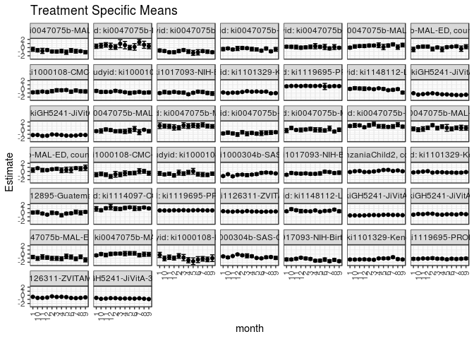

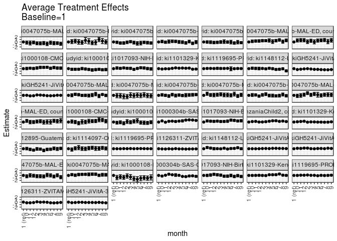

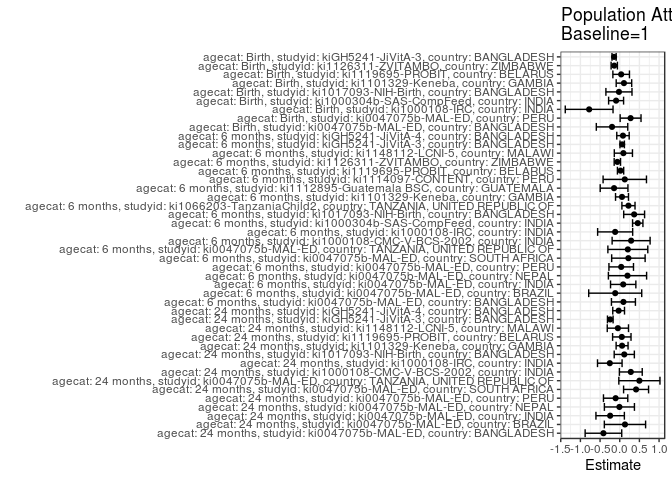

## Results Table

### Parameter: TSM

| agecat | studyid | country | intervention_level | baseline_level | estimate | ci_lower | ci_upper |
| --- | --- | --- | --- | --- | --- | --- | --- |
| Birth | ki0047075b-MAL-ED | BANGLADESH | 1 | NA | -0.7460000 | -1.1587129 | -0.3332871 |
| Birth | ki0047075b-MAL-ED | BANGLADESH | 2 | NA | -1.0477778 | -1.5283244 | -0.5672312 |
| Birth | ki0047075b-MAL-ED | BANGLADESH | 3 | NA | -1.0652174 | -1.5516837 | -0.5787511 |
| Birth | ki0047075b-MAL-ED | BANGLADESH | 4 | NA | -1.1445238 | -1.6165091 | -0.6725385 |
| Birth | ki0047075b-MAL-ED | BANGLADESH | 5 | NA | -0.5841176 | -1.1364997 | -0.0317356 |
| Birth | ki0047075b-MAL-ED | BANGLADESH | 6 | NA | -0.7316667 | -1.2312077 | -0.2321257 |
| Birth | ki0047075b-MAL-ED | BANGLADESH | 7 | NA | -1.1675000 | -1.6002755 | -0.7347245 |
| Birth | ki0047075b-MAL-ED | BANGLADESH | 8 | NA | -0.6920833 | -1.1495830 | -0.2345837 |
| Birth | ki0047075b-MAL-ED | BANGLADESH | 9 | NA | -1.4325000 | -1.9422561 | -0.9227439 |
| Birth | ki0047075b-MAL-ED | BANGLADESH | 10 | NA | -1.0836842 | -1.5505962 | -0.6167722 |
| Birth | ki0047075b-MAL-ED | BANGLADESH | 11 | NA | -0.7146154 | -1.2585683 | -0.1706625 |
| Birth | ki0047075b-MAL-ED | BANGLADESH | 12 | NA | -0.8632692 | -1.2875657 | -0.4389728 |
| Birth | ki0047075b-MAL-ED | PERU | 1 | NA | -0.3279167 | -0.5938557 | -0.0619776 |
| Birth | ki0047075b-MAL-ED | PERU | 2 | NA | 0.0840000 | -0.2487620 | 0.4167620 |
| Birth | ki0047075b-MAL-ED | PERU | 3 | NA | 0.1038095 | -0.2241932 | 0.4318123 |
| Birth | ki0047075b-MAL-ED | PERU | 4 | NA | 0.0976923 | -0.4279042 | 0.6232888 |
| Birth | ki0047075b-MAL-ED | PERU | 5 | NA | 0.1733333 | -0.2512738 | 0.5979405 |
| Birth | ki0047075b-MAL-ED | PERU | 6 | NA | 0.1600000 | -0.2679979 | 0.5879979 |
| Birth | ki0047075b-MAL-ED | PERU | 7 | NA | -0.2715000 | -0.6906102 | 0.1476102 |
| Birth | ki0047075b-MAL-ED | PERU | 8 | NA | -0.0585714 | -0.5747424 | 0.4575996 |
| Birth | ki0047075b-MAL-ED | PERU | 9 | NA | -0.0730000 | -0.5463134 | 0.4003134 |
| Birth | ki0047075b-MAL-ED | PERU | 10 | NA | -0.0060000 | -0.3634292 | 0.3514292 |
| Birth | ki0047075b-MAL-ED | PERU | 11 | NA | -0.2427586 | -0.6719516 | 0.1864344 |
| Birth | ki0047075b-MAL-ED | PERU | 12 | NA | 0.0164286 | -0.3884668 | 0.4213240 |
| Birth | ki1000108-IRC | INDIA | 1 | NA | -0.2330000 | -0.8690955 | 0.4030955 |
| Birth | ki1000108-IRC | INDIA | 2 | NA | -0.4759091 | -1.0646811 | 0.1128629 |
| Birth | ki1000108-IRC | INDIA | 3 | NA | -0.8738462 | -1.6359583 | -0.1117340 |
| Birth | ki1000108-IRC | INDIA | 4 | NA | -1.5168421 | -2.1488141 | -0.8848701 |
| Birth | ki1000108-IRC | INDIA | 5 | NA | -1.7686667 | -2.5910096 | -0.9463238 |
| Birth | ki1000108-IRC | INDIA | 6 | NA | -1.3684000 | -2.0950934 | -0.6417066 |

[output cut: 498 more lines]

### Parameter: E(Y)

| agecat | studyid | country | intervention_level | baseline_level | estimate | ci_lower | ci_upper |
| --- | --- | --- | --- | --- | --- | --- | --- |
| Birth | ki0047075b-MAL-ED | BANGLADESH | NA | NA | -0.9418605 | -1.0869834 | -0.7967375 |
| Birth | ki0047075b-MAL-ED | PERU | NA | NA | -0.0520175 | -0.1725298 | 0.0684947 |
| Birth | ki1000108-IRC | INDIA | NA | NA | -1.0105831 | -1.1973019 | -0.8238643 |
| Birth | ki1000304b-SAS-CompFeed | INDIA | NA | NA | -0.6700453 | -0.8474950 | -0.4925957 |
| Birth | ki1017093-NIH-Birth | BANGLADESH | NA | NA | -1.3499217 | -1.4444634 | -1.2553801 |
| Birth | ki1101329-Keneba | GAMBIA | NA | NA | -1.2349454 | -1.2972413 | -1.1726496 |
| Birth | ki1119695-PROBIT | BELARUS | NA | NA | -1.1448633 | -1.3544229 | -0.9353037 |
| Birth | ki1126311-ZVITAMBO | ZIMBABWE | NA | NA | -0.5154897 | -0.5413479 | -0.4896314 |
| Birth | kiGH5241-JiVitA-3 | BANGLADESH | NA | NA | -0.7778272 | -0.7968313 | -0.7588232 |
| 6 months | ki0047075b-MAL-ED | BANGLADESH | NA | NA | -0.1376763 | -0.2664642 | -0.0088885 |
| 6 months | ki0047075b-MAL-ED | BRAZIL | NA | NA | 0.9720774 | 0.8078144 | 1.1363403 |
| 6 months | ki0047075b-MAL-ED | INDIA | NA | NA | -0.7079979 | -0.8344175 | -0.5815783 |
| 6 months | ki0047075b-MAL-ED | NEPAL | NA | NA | 0.1104308 | -0.0208643 | 0.2417259 |
| 6 months | ki0047075b-MAL-ED | PERU | NA | NA | 1.0528816 | 0.9313005 | 1.1744626 |
| 6 months | ki0047075b-MAL-ED | SOUTH AFRICA | NA | NA | 0.5421785 | 0.3900443 | 0.6943126 |
| 6 months | ki0047075b-MAL-ED | TANZANIA, UNITED REPUBLIC OF | NA | NA | 0.5362213 | 0.4049390 | 0.6675036 |
| 6 months | ki1000108-CMC-V-BCS-2002 | INDIA | NA | NA | -0.5026766 | -0.6536848 | -0.3516685 |
| 6 months | ki1000108-IRC | INDIA | NA | NA | -0.5989297 | -0.7344491 | -0.4634104 |
| 6 months | ki1000304b-SAS-CompFeed | INDIA | NA | NA | -0.6657084 | -0.8024377 | -0.5289791 |
| 6 months | ki1017093-NIH-Birth | BANGLADESH | NA | NA | -0.4474038 | -0.5378167 | -0.3569909 |
| 6 months | ki1066203-TanzaniaChild2 | TANZANIA, UNITED REPUBLIC OF | NA | NA | 0.0809332 | 0.0282644 | 0.1336020 |
| 6 months | ki1101329-Keneba | GAMBIA | NA | NA | -0.1846038 | -0.2354782 | -0.1337293 |
| 6 months | ki1112895-Guatemala BSC | GUATEMALA | NA | NA | -0.0840134 | -0.1945572 | 0.0265305 |
| 6 months | ki1114097-CONTENT | PERU | NA | NA | 1.0684318 | 0.9515274 | 1.1853362 |
| 6 months | ki1119695-PROBIT | BELARUS | NA | NA | 0.5792439 | 0.5193388 | 0.6391490 |
| 6 months | ki1126311-ZVITAMBO | ZIMBABWE | NA | NA | 0.3105514 | 0.2848767 | 0.3362262 |
| 6 months | ki1148112-LCNI-5 | MALAWI | NA | NA | 0.4499404 | 0.3788501 | 0.5210308 |
| 6 months | kiGH5241-JiVitA-3 | BANGLADESH | NA | NA | -0.5935161 | -0.6130518 | -0.5739805 |
| 6 months | kiGH5241-JiVitA-4 | BANGLADESH | NA | NA | -0.3898055 | -0.4270507 | -0.3525603 |
| 24 months | ki0047075b-MAL-ED | BANGLADESH | NA | NA | -0.8192925 | -0.9412667 | -0.6973182 |
| 24 months | ki0047075b-MAL-ED | BRAZIL | NA | NA | 0.4626233 | 0.2567495 | 0.6684971 |
| 24 months | ki0047075b-MAL-ED | INDIA | NA | NA | -0.9516520 | -1.0670654 | -0.8362385 |
| 24 months | ki0047075b-MAL-ED | NEPAL | NA | NA | -0.3749123 | -0.4886073 | -0.2612173 |
| 24 months | ki0047075b-MAL-ED | PERU | NA | NA | 0.1111982 | -0.0118399 | 0.2342362 |
| 24 months | ki0047075b-MAL-ED | SOUTH AFRICA | NA | NA | 0.4090301 | 0.2879441 | 0.5301161 |
| 24 months | ki0047075b-MAL-ED | TANZANIA, UNITED REPUBLIC OF | NA | NA | 0.0547975 | -0.0703378 | 0.1799328 |
| 24 months | ki1000108-CMC-V-BCS-2002 | INDIA | NA | NA | -0.5571505 | -0.6585247 | -0.4557763 |
| 24 months | ki1000108-IRC | INDIA | NA | NA | -0.7458150 | -0.8368180 | -0.6548120 |
| 24 months | ki1017093-NIH-Birth | BANGLADESH | NA | NA | -0.9115790 | -1.0095022 | -0.8136559 |
| 24 months | ki1101329-Keneba | GAMBIA | NA | NA | -0.8099290 | -0.8570608 | -0.7627972 |
| 24 months | ki1119695-PROBIT | BELARUS | NA | NA | 0.6874295 | 0.5756922 | 0.7991668 |
| 24 months | ki1148112-LCNI-5 | MALAWI | NA | NA | -0.0477709 | -0.1296526 | 0.0341109 |
| 24 months | kiGH5241-JiVitA-3 | BANGLADESH | NA | NA | -1.2978031 | -1.3210763 | -1.2745298 |
| 24 months | kiGH5241-JiVitA-4 | BANGLADESH | NA | NA | -1.2231088 | -1.2549632 | -1.1912543 |

### Parameter: ATE

| agecat | studyid | country | intervention_level | baseline_level | estimate | ci_lower | ci_upper |
| --- | --- | --- | --- | --- | --- | --- | --- |
| Birth | ki0047075b-MAL-ED | BANGLADESH | 1 | 1 | 0.0000000 | 0.0000000 | 0.0000000 |
| Birth | ki0047075b-MAL-ED | BANGLADESH | 2 | 1 | -0.3017778 | -0.9352263 | 0.3316707 |
| Birth | ki0047075b-MAL-ED | BANGLADESH | 3 | 1 | -0.3192174 | -0.9571683 | 0.3187336 |
| Birth | ki0047075b-MAL-ED | BANGLADESH | 4 | 1 | -0.3985238 | -1.0255024 | 0.2284547 |
| Birth | ki0047075b-MAL-ED | BANGLADESH | 5 | 1 | 0.1618824 | -0.5276522 | 0.8514169 |
| Birth | ki0047075b-MAL-ED | BANGLADESH | 6 | 1 | 0.0143333 | -0.6336429 | 0.6623095 |
| Birth | ki0047075b-MAL-ED | BANGLADESH | 7 | 1 | -0.4215000 | -1.0195189 | 0.1765189 |
| Birth | ki0047075b-MAL-ED | BANGLADESH | 8 | 1 | 0.0539167 | -0.5622310 | 0.6700643 |
| Birth | ki0047075b-MAL-ED | BANGLADESH | 9 | 1 | -0.6865000 | -1.3423836 | -0.0306164 |
| Birth | ki0047075b-MAL-ED | BANGLADESH | 10 | 1 | -0.3376842 | -0.9608526 | 0.2854841 |
| Birth | ki0047075b-MAL-ED | BANGLADESH | 11 | 1 | 0.0313846 | -0.6514160 | 0.7141853 |
| Birth | ki0047075b-MAL-ED | BANGLADESH | 12 | 1 | -0.1172692 | -0.7091809 | 0.4746424 |
| Birth | ki0047075b-MAL-ED | PERU | 1 | 1 | 0.0000000 | 0.0000000 | 0.0000000 |
| Birth | ki0047075b-MAL-ED | PERU | 2 | 1 | 0.4119167 | -0.0140576 | 0.8378910 |
| Birth | ki0047075b-MAL-ED | PERU | 3 | 1 | 0.4317262 | 0.0094592 | 0.8539931 |
| Birth | ki0047075b-MAL-ED | PERU | 4 | 1 | 0.4256090 | -0.1634371 | 1.0146550 |
| Birth | ki0047075b-MAL-ED | PERU | 5 | 1 | 0.5012500 | 0.0002362 | 1.0022638 |
| Birth | ki0047075b-MAL-ED | PERU | 6 | 1 | 0.4879167 | -0.0159740 | 0.9918073 |
| Birth | ki0047075b-MAL-ED | PERU | 7 | 1 | 0.0564167 | -0.4399470 | 0.5527804 |
| Birth | ki0047075b-MAL-ED | PERU | 8 | 1 | 0.2693452 | -0.3113062 | 0.8499967 |
| Birth | ki0047075b-MAL-ED | PERU | 9 | 1 | 0.2549167 | -0.2879913 | 0.7978247 |
| Birth | ki0047075b-MAL-ED | PERU | 10 | 1 | 0.3219167 | -0.1235934 | 0.7674267 |
| Birth | ki0047075b-MAL-ED | PERU | 11 | 1 | 0.0851580 | -0.4197481 | 0.5900642 |
| Birth | ki0047075b-MAL-ED | PERU | 12 | 1 | 0.3443452 | -0.1400759 | 0.8287664 |
| Birth | ki1000108-IRC | INDIA | 1 | 1 | 0.0000000 | 0.0000000 | 0.0000000 |
| Birth | ki1000108-IRC | INDIA | 2 | 1 | -0.2429091 | -1.1096674 | 0.6238492 |
| Birth | ki1000108-IRC | INDIA | 3 | 1 | -0.6408462 | -1.6335356 | 0.3518433 |
| Birth | ki1000108-IRC | INDIA | 4 | 1 | -1.2838421 | -2.1805060 | -0.3871782 |
| Birth | ki1000108-IRC | INDIA | 5 | 1 | -1.5356667 | -2.5753134 | -0.4960199 |
| Birth | ki1000108-IRC | INDIA | 6 | 1 | -1.1354000 | -2.1011644 | -0.1696356 |

[output cut: 498 more lines]

### Parameter: PAR

| agecat | studyid | country | intervention_level | baseline_level | estimate | ci_lower | ci_upper |
| --- | --- | --- | --- | --- | --- | --- | --- |
| Birth | ki0047075b-MAL-ED | BANGLADESH | 1 | NA | -0.1958605 | -0.5954890 | 0.2037681 |
| Birth | ki0047075b-MAL-ED | PERU | 1 | NA | 0.2758991 | 0.0106491 | 0.5411492 |
| Birth | ki1000108-IRC | INDIA | 1 | NA | -0.7775831 | -1.3847921 | -0.1703741 |
| Birth | ki1000304b-SAS-CompFeed | INDIA | 1 | NA | -0.0925069 | -0.2827524 | 0.0977387 |
| Birth | ki1017093-NIH-Birth | BANGLADESH | 1 | NA | -0.0201069 | -0.3518307 | 0.3116169 |
| Birth | ki1101329-Keneba | GAMBIA | 1 | NA | 0.1068591 | -0.0901124 | 0.3038306 |
| Birth | ki1119695-PROBIT | BELARUS | 1 | NA | 0.0362244 | -0.1745749 | 0.2470236 |
| Birth | ki1126311-ZVITAMBO | ZIMBABWE | 1 | NA | -0.1388742 | -0.2190784 | -0.0586699 |
| Birth | kiGH5241-JiVitA-3 | BANGLADESH | 1 | NA | -0.1439698 | -0.1969396 | -0.0909999 |
| 6 months | ki0047075b-MAL-ED | BANGLADESH | 1 | NA | 0.0939026 | -0.2109023 | 0.3987075 |
| 6 months | ki0047075b-MAL-ED | BRAZIL | 1 | NA | -0.1149465 | -0.7888237 | 0.5589308 |
| 6 months | ki0047075b-MAL-ED | INDIA | 1 | NA | 0.0880021 | -0.2337575 | 0.4097617 |
| 6 months | ki0047075b-MAL-ED | NEPAL | 1 | NA | 0.1972641 | -0.2885163 | 0.6830446 |
| 6 months | ki0047075b-MAL-ED | PERU | 1 | NA | 0.0376290 | -0.2746295 | 0.3498875 |
| 6 months | ki0047075b-MAL-ED | SOUTH AFRICA | 1 | NA | 0.2201993 | -0.2050218 | 0.6454204 |
| 6 months | ki0047075b-MAL-ED | TANZANIA, UNITED REPUBLIC OF | 1 | NA | 0.2058245 | -0.3015493 | 0.7131983 |
| 6 months | ki1000108-CMC-V-BCS-2002 | INDIA | 1 | NA | 0.2893472 | -0.1935923 | 0.7722867 |
| 6 months | ki1000108-IRC | INDIA | 1 | NA | -0.1166440 | -0.5620972 | 0.3288091 |
| 6 months | ki1000304b-SAS-CompFeed | INDIA | 1 | NA | 0.4579387 | 0.3262917 | 0.5895856 |
| 6 months | ki1017093-NIH-Birth | BANGLADESH | 1 | NA | 0.3662629 | 0.1008168 | 0.6317089 |
| 6 months | ki1066203-TanzaniaChild2 | TANZANIA, UNITED REPUBLIC OF | 1 | NA | 0.2218293 | 0.0550458 | 0.3886129 |
| 6 months | ki1101329-Keneba | GAMBIA | 1 | NA | 0.0577513 | -0.1068335 | 0.2223361 |
| 6 months | ki1112895-Guatemala BSC | GUATEMALA | 1 | NA | -0.1442912 | -0.4968524 | 0.2082701 |
| 6 months | ki1114097-CONTENT | PERU | 1 | NA | 0.1282651 | -0.4232608 | 0.6797910 |
| 6 months | ki1119695-PROBIT | BELARUS | 1 | NA | 0.0208197 | -0.0589402 | 0.1005796 |
| 6 months | ki1126311-ZVITAMBO | ZIMBABWE | 1 | NA | -0.0605883 | -0.1414521 | 0.0202756 |
| 6 months | ki1148112-LCNI-5 | MALAWI | 1 | NA | 0.0926677 | -0.1380862 | 0.3234216 |
| 6 months | kiGH5241-JiVitA-3 | BANGLADESH | 1 | NA | 0.0626991 | 0.0066185 | 0.1187796 |
| 6 months | kiGH5241-JiVitA-4 | BANGLADESH | 1 | NA | 0.0823643 | -0.0754270 | 0.2401556 |
| 24 months | ki0047075b-MAL-ED | BANGLADESH | 1 | NA | -0.4145866 | -0.8796795 | 0.0505064 |
| 24 months | ki0047075b-MAL-ED | BRAZIL | 1 | NA | 0.1329804 | -0.3915215 | 0.6574823 |
| 24 months | ki0047075b-MAL-ED | INDIA | 1 | NA | -0.2436520 | -0.6050522 | 0.1177483 |
| 24 months | ki0047075b-MAL-ED | NEPAL | 1 | NA | -0.0083333 | -0.3903894 | 0.3737227 |
| 24 months | ki0047075b-MAL-ED | PERU | 1 | NA | -0.1045711 | -0.4135044 | 0.2043623 |
| 24 months | ki0047075b-MAL-ED | SOUTH AFRICA | 1 | NA | 0.4154094 | 0.0979179 | 0.7329010 |
| 24 months | ki0047075b-MAL-ED | TANZANIA, UNITED REPUBLIC OF | 1 | NA | 0.4997049 | -0.0232464 | 1.0226562 |
| 24 months | ki1000108-CMC-V-BCS-2002 | INDIA | 1 | NA | 0.2814804 | -0.0090498 | 0.5720106 |
| 24 months | ki1000108-IRC | INDIA | 1 | NA | -0.2528150 | -0.5649899 | 0.0593599 |
| 24 months | ki1017093-NIH-Birth | BANGLADESH | 1 | NA | 0.1154448 | -0.1408184 | 0.3717079 |
| 24 months | ki1101329-Keneba | GAMBIA | 1 | NA | 0.0598210 | -0.0918795 | 0.2115215 |
| 24 months | ki1119695-PROBIT | BELARUS | 1 | NA | 0.0526063 | -0.1814563 | 0.2866689 |
| 24 months | ki1148112-LCNI-5 | MALAWI | 1 | NA | -0.0472709 | -0.3173271 | 0.2227854 |
| 24 months | kiGH5241-JiVitA-3 | BANGLADESH | 1 | NA | -0.2403705 | -0.3118783 | -0.1688627 |
| 24 months | kiGH5241-JiVitA-4 | BANGLADESH | 1 | NA | -0.0281088 | -0.1775336 | 0.1213161 |